# PS4: Descriptive Statistics and Central Limit Theorem

Ji H. Kang

11/1/2020

```r
library(ggplot2)
library(tidyverse)
```

# 1. Compare differently distributed data

## 1.1 Human Bodies

### What kind of measure is human height?

This problem set goes over working with human heights. *Nominal* values have no numerical meaning such as colors, gender, or car model. *Ordinal* data utilizes numerical values but the order matters. This can be seen in surveys where you indicate “1 for unsatisfactory up to 5 for satisfactory”. *Interval* or “Difference”, the difference in values are the same throughout the entire scale. The one downfall is that it does not have an absolute 0. Because height does not fit into these, it is **ratio** data. There is an absolute 0 for height, the values can be compared with each other (Eg. Who is taller or shorter than one another). Additionally, since no one can be “negative height”, it’s expected the height values are all positive numerical values.

### How should human height be measured?

Since continuous variables can be represented with an infinite number of real values, human height is **continuous**. Discrete values contain a finite set of values. A human height could be 170 cm or it could actually be 169.48374987984789… cm.

#### Loading data to be used

```r
heights <- read.delim("../../Data/fatherson.csv.bz2") #have to tab delim. Reading just the csv would tab separate records with only one column.
cat("The available stats are:", names(heights), "\n")
```

```
## The available stats are: fheight sheight
```

**Context:** “fheight” means “father’s height” and “sheight” means “son’s height” The data this problem set is using is comprised of a father’s height and son’s height in centimeters (cm). This will go over some basic analysis on the **fathers** first.

#### How many observations do we have?

There are 1078 records in the data.

#### Are there any missing observations?

There are 0 record(s) missing in the data.

#### Are there any unreasonable values?

```r
summary(heights$fheight)
```

```
##    Min. 1st Qu.  Median    Mean 3rd Qu.    Max.
##   149.9   167.1   172.1   171.9   176.8   191.6
```

With a minimum height of 149.9 cm, or roughly 4.92 feet, and a maximum of 191.6 cm, or roughly 6.29 feet, there does not seem to be any unreasonable values. An average of 171.9 cm is equal to 5.64 feet which may seem short by 21st century standards. However, this was during the 19th century when people were much shorter on average. There does not seem to be any abnormal or unreasonable values in the data for the fathers’ heights.

#### Computing the mean, median, standard deviation, and range of the heights

```r
fheight_mean <- mean(heights$fheight)
fheight_median <- median(heights$fheight)
cat("The mean for the fathers' height is:", fheight_mean , "cm.\n")
```

```
## The mean for the fathers' height is: 171.9252 cm.
```

```r
cat("The median for the fathers' height is:", fheight_median, "cm.\n")
```

```
## The median for the fathers' height is: 172.1 cm.
```

```r
cat("The standard deviation for the fathers' height is:", sd(heights$fheight), "cm.\n")
```

```
## The standard deviation for the fathers' height is: 6.972346 cm.
```

```r
#Used max() and min() over range() since range() returns the max and min. It doesn't calculate it.
cat("The range for the fathers' heights is:", max(heights$fheight) - min(heights$fheight), "cm.\n")
```

```
## The range for the fathers' heights is: 41.7 cm.
```

It seems that the median for the heights is larger than the mean for the heights. This indicates half the sample population is below 172.1 cm and the other half above. While the average notes that the height is 171.9252 cm, it means that the data has a skew to the left although it seems subtle. It indicates there are more outliers in the bottom half of the data than the top; and as a result, brings the average to be lower than the mean. Another thing to note is the standard deviations in terms of the mean. With the standard deviation being roughly 6.97 cm and the mean being roughly 171.92 cm, we can expect 68% of the heights to fall within 1 standard deviation, 95% within 2, and 99.7% within 3.

#### Plotting a histogram to visualize fathers’ heights

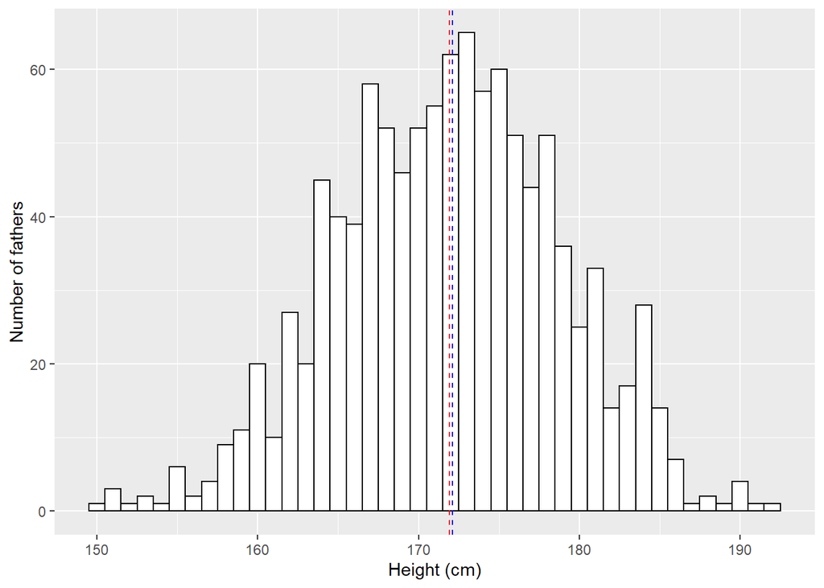

```r
ggplot(heights, aes(x=fheight)) +
  geom_histogram(binwidth=1, color="black", fill="white") + #Plotting  the data
  xlab("Height (cm)") + ylab("Number of fathers") + #Change axis titles
  geom_vline(xintercept=fheight_mean, linetype="dashed", color="red") + #Plotting the mean
  geom_vline(xintercept=fheight_median, linetype="dashed", color="blue") #Plotting the median
```

Plotting the height of all the fathers along with the mean and median, showcases a lot. Because the data we’re dealing with is *continuous*, it’ll be a *continuous distribution*. In this case, it resembles a **normal distribution**. The mean and median are very close together which helps imply this further.

## 1.2 Human Influence

We’ll be looking into human influence on the data. We’ll be utilizing the **Microsoft Academic Graph (MAG)**. It contains two columns: *paper id* and the *citations*, the number of times the paper has been cited. We’ll only be utilizing the number of citations however.

#### What kind of measure is this? What kind of valid figures would be expected?

Since the number of citations can be 0 to any whole positive integer, it has a **positive discrete** value. Since there is a “true zero”, I believe this to also be **ratio**. Since research papers are constantly being published as new discoveries are made, there’re many niche applications of each paper. This can lead to some never being utilized, utilized a few times, and perhaps utilized a thousands of times. It can be expected that the majority of them will be cited anywhere from 0 to a few dozen – with perhaps groundbreaking research having the thousands of citations.

#### Loading data to be used

```r
cites <- read.csv("../../Data/mag-in-citations.csv.bz2") %>%
  select(citations)#Utilizied read.csv here. Using read.delim combined both columns for some reason. Unsure about this.
```

#### Basic Analysis

```r
cat("The available columns are:", names(cites), "\n")
```

```
## The available columns are: citations
```

```r
cat("There are", nrow(cites), "observations.\n")
```

```
## There are 388258 observations.
```

```r
cat("There are", sum(is.na(cites$citations)), "observations missing.\n")
```

```
## There are 0 observations missing.
```

There are 388258 observations in the data. There are 0 observation(s) missing in the data. The highest number of citations is 18682 while the lowest number of citations is 0. The range of this is 18682.

#### Computing the mean, median, mode, standard deviation, and range of the number of citations

```r
cite_mean <- mean(cites$citations)
cite_median <- median(cites$citations)
cat("The mean is:", cite_mean, "\n")
```

```
## The mean is: 15.61223
```

```r
cat("The median is:", cite_median, "\n")
```

```
## The median is: 3
```

```r
cat("The mode is:", modeest::mlv(cites$citations, method="mfv"), "\n")
```

```
## The mode is: 0
```

```r
cat("The standard deviation is:", sd(cites$citations), "\n")
```

```
## The standard deviation is: 78.39079
```

We can see that the mean, 15.61223 citations, is larger than the median, 3 citations. This would indicate that half of the papers have 3 or fewer citations and the other half have 3 or more. The mean being 15.61223 would signify that there are some quite a number of positive outliers that would influence the average to be more than 12 citations more than the median. The standard deviation being much larger than the mean (~78 citations compaed to 15 citations) would indicate that the data points are much more spread out. A smaller standard deviation would indicate the data points are closely clustered together. As shown with a median number of citations of 3, we can safely assume there are a few large outliers. Looking at the mean verses the median, the mean is larger. This would indicate a skew to the right.

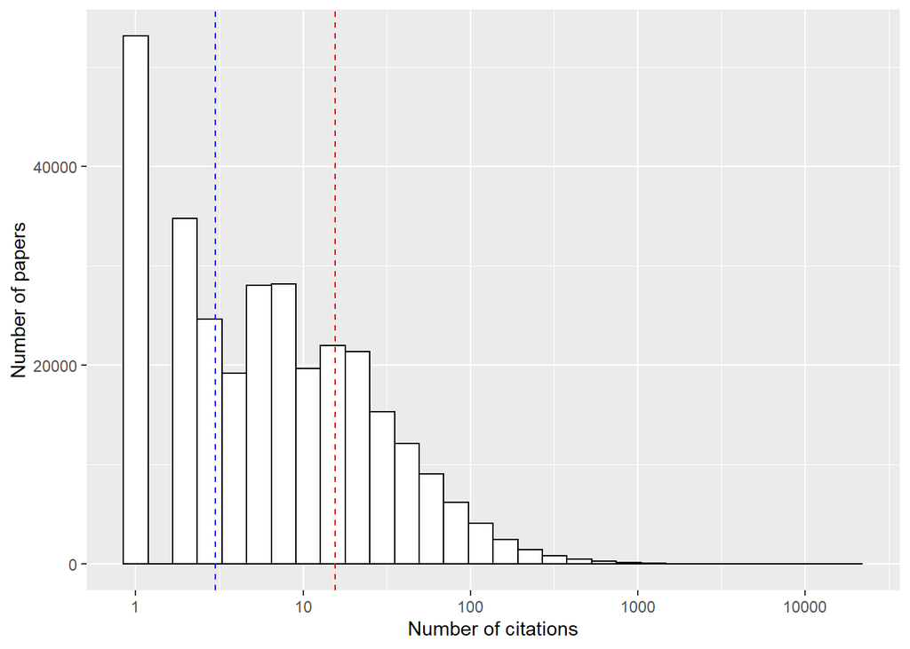

```r
ggplot(cites, aes(x=citations)) +
  geom_histogram(color="black", fill="white") + #Plotting  the data
  scale_x_log10() +
  xlab("Number of citations") + ylab("Number of papers") + #Change axis titles
  geom_vline(xintercept=cite_mean, linetype="dashed", color="red") + #Plotting the mean
  geom_vline(xintercept=cite_median, linetype="dashed", color="blue") #Plotting the median
```

#### Summary of findings on human bodies and influence

If this is asking me to correlate the two data sets together, I’m afraid I don’t see a connection. Through this problem set, it’s taught me a few things about the time of data we work with. Something like human height resembles a normal distribution as shown with the mean and median being very close together - further emphasized by looking at the standard deviation. Perhaps things in nature follow statistical principles of the bell curve. Eg. More often than not, an animal will be within a certain weight group, fathers will be within a certain height, and so on. Reflecting back on the citation information and things relating to Pareto distributions, it’s common to see in things such as “Research paper citations” and income. There’s a skew in the way the data is represented. Since a human height can’t be 0 cm, it the father son’s height data didn’t follow this trend. We see the skew because of the clustering around 0 citations for the MAG dataset.

# 2 Explore Central Limit Thereom

*Central Limit Theorem* states that the means of random numbers tend to be normally distributed if the sample size gets large, and the variance of the mean tends to be 1/S (Var(X)), where S is the sample size and X is the random variable means. This portion will be exploring this theorem.

## Calculating the expected value and variance of this random variable

### Conducting further experiments

To further view random variable distribution, I’ll be using a size N = 1000.

```r
rand_nums <- sample(c(-1, 1), 1000, replace=TRUE)
```

### Graphing our new set of data

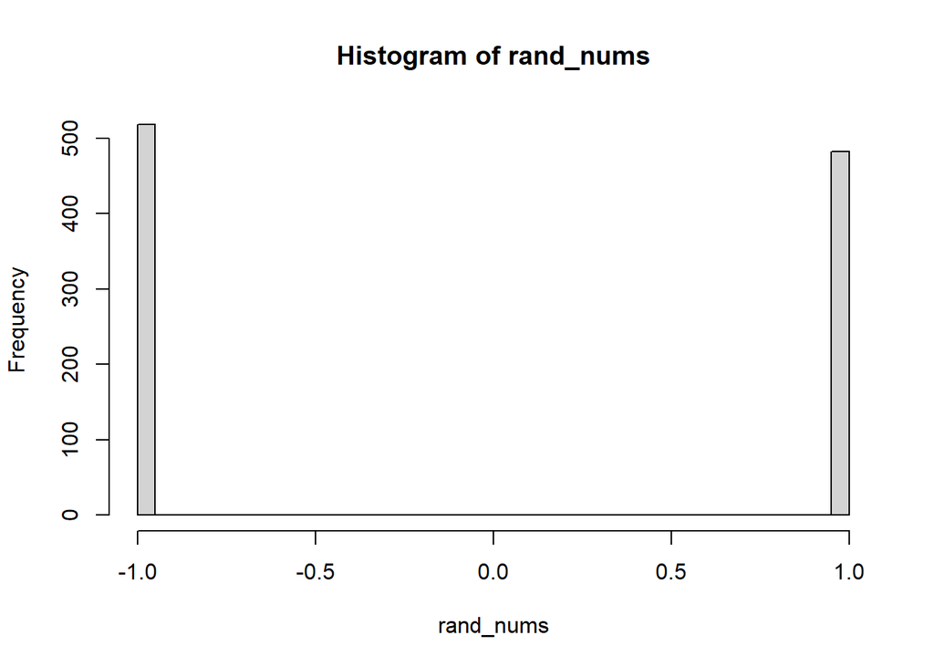

```r
hist(rand_nums, breaks=30)
```

We can see both values have a similar frequency. Because of the number of outcomes only being limited to 2 states (1 and -1), we appear to have a **Bernoulli** distribution.

### Calculating mean and variance of the data

```r
cat("The mean of the data is", mean(rand_nums), "\n")
```

```
## The mean of the data is -0.036
```

```r
cat("The variance of the data is", var(rand_nums), "\n")
```

```
## The variance of the data is 0.9997037
```

### Creating 1000 pairs of random numbers.

```r
rand_pairs_means <- c() #To hold 1000 means of pairs of random numbers
for(i in 1:1000) {
  rand_pairs_means[i] <- mean(sample(c(-1, 1), 2, replace=TRUE)) #Create 2 random variables, average them, then store
}
```